# Developing Data Products Assign-4 w/ Gapminder Data

2/10/2021

## Introduction

This peer assessed assignment has two parts.

- First, you will create a Shiny application and deploy it on Rstudio’s servers.
- Second, you will use Slidify or Rstudio Presenter to prepare a reproducible pitch presentation about your application.

Shiny Application can be found [HERE:](https://barteec.shinyapps.io/Developing_Data_Products_Assign_4_Gapminder_Data/)

Shiny Application source code can be found [HERE:](https://github.com/barteec/Developing-Data-Products-Week-4-Course-Project)

## Shiny Application Overview

- Shiny is an R package that makes it easy to build interactive web apps straight from R. You can host standalone apps on a webpage or embed them in R Markdown documents or build dashboards.
- The source code consists of in one file in the Project_shiny folder: [app.R](https://github.com/barteec/Developing-Data-Products-Week-4-Course-Project/tree/main/Project_shiny)
- The application is hosted on [shinyapps.io](https://www.shinyapps.io/) by RStudio

## The data that was used

An excerpt of the data available HERE, "For each of 142 countries, the package provides values for life expectancy, Gross Domestic Product (GDP), and population, every five years, from 1952 to 2007. Data can be reused freely but please attribute the original data source

```r
library(kableExtra)
library(gapminder)
data <- gapminder
kable(head(data))
```

| country | continent | year | lifeExp | pop | gdpPercap |
| --- | --- | --- | --- | --- | --- |
| Afghanistan | Asia | 1952 | 28.801 | 8425333 | 779.4453 |
| Afghanistan | Asia | 1957 | 30.332 | 9240934 | 820.8530 |
| Afghanistan | Asia | 1962 | 31.997 | 10267083 | 853.1007 |
| Afghanistan | Asia | 1967 | 34.020 | 11537966 | 836.1971 |
| Afghanistan | Asia | 1972 | 36.088 | 13079460 | 739.9811 |
| Afghanistan | Asia | 1977 | 38.438 | 14880372 | 786.1134 |

## The Graph and Tables

There are two tabs in main panel as below:

- Gapminder Plot: This displays plot for corresponding dataframe
- GapminderTable: This displays a searchable-interactive Table for corresponding dataframe

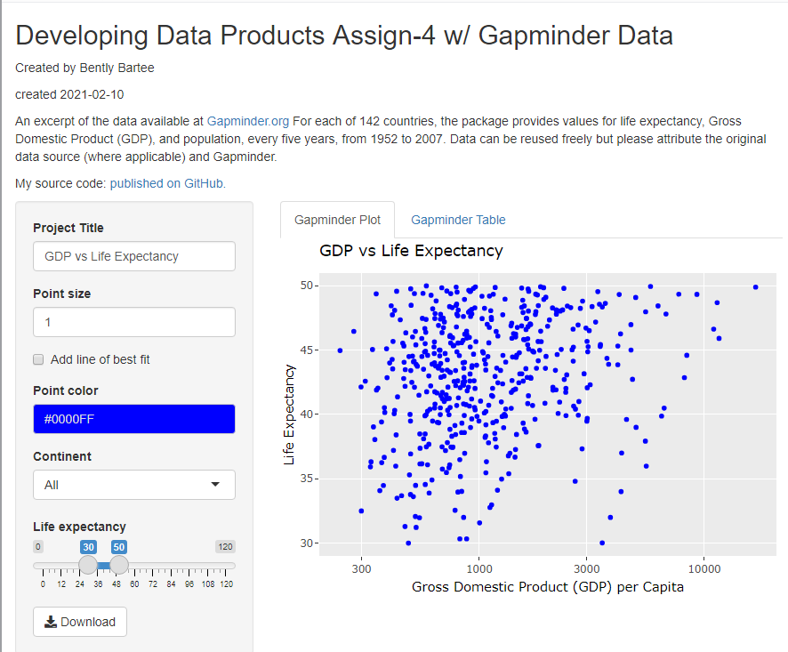

## Here is where you can view the Project?

Shiny Application can be found [HERE:](https://barteec.shinyapps.io/Developing_Data_Products_Assign_4_Gapminder_Data/)

Shiny Application source code can be found [HERE:](https://github.com/barteec/Developing-Data-Products-Week-4-Course-Project)

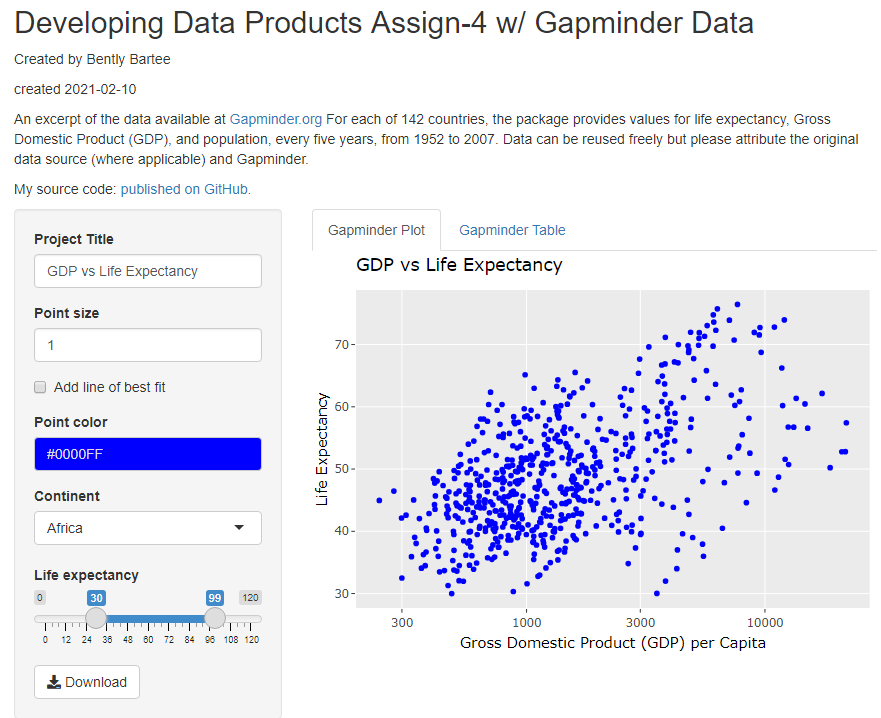